# BeerAdvocate Data Analysis

Francisco Javier Carela Ferrer

September 2023

To carry out this task, the free software R and the R Markdown editing tool will be used.

# Preliminary analysis

First we load the require libraries:

```r
library(data.table) # Handle large databases quickly
library(readr) # Load csv
library(DT) # Presentation of tables in RMarkdown
library(zoo) # Manipulation of dates, time series, ... etc.
library(Amelia) # Useful to work with NA data
library(ggplot2) # Graphical representation
library(psych) # Obtaining correlograms
```

In this first phase, the data is loaded for correct processing.

```r
beer_reviews <- read_csv("beer_reviews.csv")
beer_reviews<-data.table(beer_reviews)
```

We will use the *datatatable* library, which is useful when working with large databases in R, as in our case.

The dataset has 13 columns, which indicate:

- **brewery_id**: Identifier of the brewery manufacturer.
- **brewery_name**: Name of the beer manufacturer.
- **review_time**: Date of the review, expressed in seconds since January 1, 1970.
- **review_overall**: Overall rating of the beer.
- **review_aroma**: Aroma rating.
- **review_appearance**: Appearance rating.
- **review_profilename**: Name of the user who made the review.
- **beer_style**: Beer style.
- **review_palate**: Palate rating.
- **review_taste**: Taste/flavor evaluation.
- **beer_name**: Beer name.
- **beer_abv**: % alcohol of the beer.
- **beer_beerid**: Beer identifier.

To obtain this information you can simply access a generic beerAdvocate page such as https://www.beeradvocate.com/beer/profile/23222/78820/.

## Exploration of the dataset

Before starting, a brief preliminary analysis of our set and a preprocessing of the data is going to be done.

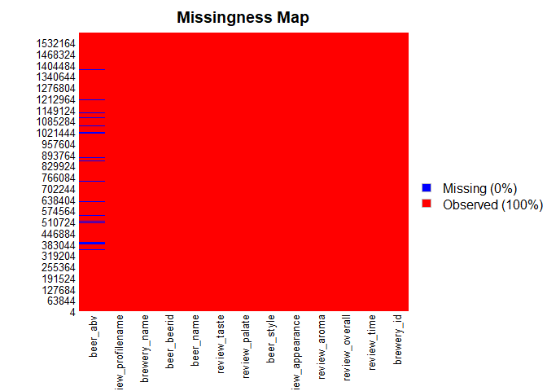

```r
missmap(beer_reviews,col=c("blue","red"),legend=TRUE)
```

With this graph we observe that the variable *beer_abv* has some missing data (NA), but the rest of the variables are complete. As we have too many variables to visualize, let’s make a summary:

```r
summary(beer_reviews)
```

```
##    brewery_id    brewery_name        review_time        review_overall
##  Min.   :    1   Length:1586614     Min.   :8.407e+08   Min.   :0.000
##  1st Qu.:  143   Class :character   1st Qu.:1.173e+09   1st Qu.:3.500
##  Median :  429   Mode  :character   Median :1.239e+09   Median :4.000
##  Mean   : 3130                      Mean   :1.224e+09   Mean   :3.816
##  3rd Qu.: 2372                      3rd Qu.:1.289e+09   3rd Qu.:4.500
##  Max.   :28003                      Max.   :1.326e+09   Max.   :5.000
##
##   review_aroma   review_appearance review_profilename  beer_style
##  Min.   :1.000   Min.   :0.000     Length:1586614     Length:1586614
##  1st Qu.:3.500   1st Qu.:3.500     Class :character   Class :character
##  Median :4.000   Median :4.000     Mode  :character   Mode  :character
##  Mean   :3.736   Mean   :3.842
##  3rd Qu.:4.000   3rd Qu.:4.000
##  Max.   :5.000   Max.   :5.000
##
##  review_palate    review_taste    beer_name            beer_abv
##  Min.   :1.000   Min.   :1.000   Length:1586614     Min.   : 0.01
##  1st Qu.:3.500   1st Qu.:3.500   Class :character   1st Qu.: 5.20
##  Median :4.000   Median :4.000   Mode  :character   Median : 6.50
##  Mean   :3.744   Mean   :3.793                      Mean   : 7.04
##  3rd Qu.:4.000   3rd Qu.:4.500                      3rd Qu.: 8.50
##  Max.   :5.000   Max.   :5.000                      Max.   :57.70
##                                                     NA's   :67785
##   beer_beerid
##  Min.   :    3
##  1st Qu.: 1717
##  Median :13906
##  Mean   :21713
##  3rd Qu.:39441
##  Max.   :77317
##
```

A priori, it does not seem that we have errors derived from counting, or radically different data within the set. We note that, the variables that give us information about the users’ opinion about the beers are : **review_overall** ,**review_aroma**, **review_appearance**, **review_palate**, **review_taste**. All are continuous variables that take values in the interval [0,5].

Since these are the variables that provide us with the most information, we can perform a correlation analysis between them:

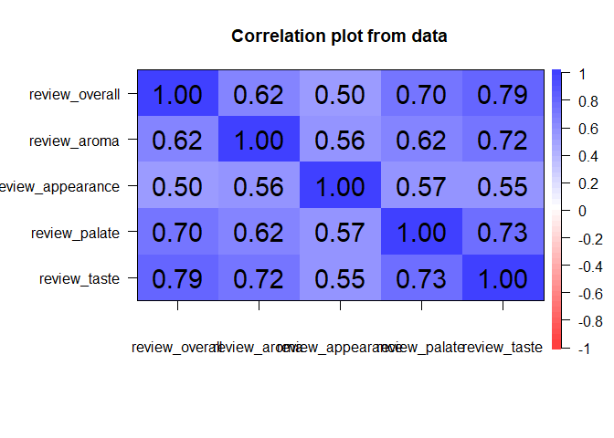

```r
beer_analysis <- beer_reviews[,c("review_overall" ,"review_aroma", "review_appearance", "review_palate", "review_taste")]
corPlot(beer_analysis, cex = 1.2, tl.cex = 0.00001,addCoef.col = 1,cl.cex = 0.5)
```

As we can see, they all have a positive correlation. In addition the review_overall variable is strongly correlated with the others, which makes sense, as it is calculated based on the others.

Finally we observe if there are duplicate rows

```r
summary(duplicated(beer_reviews))
```

```
##    Mode   FALSE
## logical 1586614
```

## Debugging the dataset

Since we are not finding duplicate data or values that are NA completely, we are not going to delete any observations. We are going to change the **review_time** variable to date format:

```r
mydates<-beer_reviews$review_time
class(mydates) = c('POSIXt','POSIXct')
beer_reviews$review_time<-mydates
summary(beer_reviews$review_time)
```

```
##                  Min.               1st Qu.                Median
## "1996-08-22 02:00:01" "2007-03-07 00:36:28" "2009-04-08 17:01:21"
##                  Mean               3rd Qu.                  Max.
## "2008-10-15 18:48:00" "2010-11-01 00:40:05" "2012-01-11 13:35:48"
```

# Which beer to choose and based on what criteria?

To choose the 3 best beers, I would take into account 2 criteria:

- **Criterion 1**: Sufficient number of reviews. For example >= 15 reviews. For this we will work with the variable *beer_beerid*.
- **Criterion 2**:The highest average overall rating (*review_overall*).

To establish the first criterion we can perform the following filtering:

```r
beer_reviews$beer_beerid<-factor(beer_reviews$beer_beerid) # We transform it into a factor to work better

group_mean<-beer_reviews[ , .(means = mean(review_overall)), by = beer_beerid]
total<-beer_reviews[ , .N, by = beer_beerid]
beers_comparison<-cbind(group_mean,total[,c("N")])
#setnames(beers_comparison, old, new)

beers_comparison<-beers_comparison[N>=15,] # Criterion 1
```

We can see the frequency distribution of the resulting variable by number of observations:

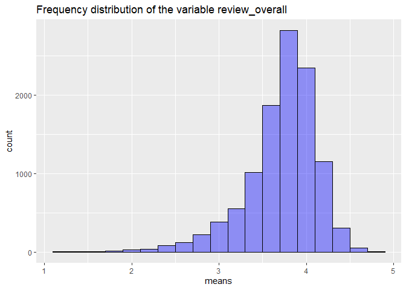

```r
pl <- ggplot(beers_comparison, aes(x=means))
pl +  geom_histogram(binwidth = 0.2, col='black', fill='blue', alpha=0.4) + ggtitle('Frequency distribution of the variable review_overall')
```

```r
setorder(beers_comparison, -means) # Criterion 2
datatable(beers_comparison)
```

|  | beer_beerid | means | N |
| --- | --- | --- | --- |
| 1 | 63649 | 4.84848484848485 | 33 |
| 2 | 44910 | 4.82051282051282 | 39 |
| 3 | 8626 | 4.76829268292683 | 41 |
| 4 | 24273 | 4.75 | 28 |
| 5 | 68548 | 4.73076923076923 | 65 |
| 6 | 58610 | 4.68461538461538 | 65 |
| 7 | 70356 | 4.64444444444444 | 45 |
| 8 | 44112 | 4.64130434782609 | 46 |
| 9 | 21625 | 4.63461538461539 | 26 |
| 10 | 23413 | 4.63380281690141 | 71 |

[output cut: 10988 more lines]

We observe that the beers have a representative number of reviews to be able to conclude that they are the best on the basis of this criterion.

```r
ids_comparison<-apply(beers_comparison[1:3,c("beer_beerid")],1, as.numeric) # Ids we are going to search in the main dataset

unique(beer_reviews[beer_beerid==ids_comparison[1],c("beer_name")])
```

```
##      beer_name
## 1: Rare D.O.S.
```

```r
unique(beer_reviews[beer_beerid==ids_comparison[2],c("beer_name")])
```

```
##      beer_name
## 1: Dirty Horse
```

```r
unique(beer_reviews[beer_beerid==ids_comparison[3],c("beer_name")])
```

```
##                      beer_name
## 1: Southampton Berliner Weisse
```

Therefore, the best beers based on this criterion are **Rare D.O.S.** , **Dirty Horse** and **Southampton Berliner Weisse**.

# Recommendation based on aroma and appearance

We will perform a similar procedure, but changing Criterion 2 (*review_overall*) to *review_arome* and *review_appearance*.

```r
beer_reviews$beer_beerid<-factor(beer_reviews$beer_beerid) # We transform it into a factor to work better

aroma_mean<-beer_reviews[ , .(aroma_mean = mean(review_aroma)), by = beer_beerid] # Average per aroma of each beer
app_mean<-beer_reviews[ , .(app_mean = mean(review_appearance)), by = beer_beerid] # Average beer per appearance
total<-beer_reviews[ , .N, by = beer_beerid]
beers_comparison<-cbind(aroma_mean,app_mean[,c("app_mean")],total[,c("N")])
#setnames(beers_comparison, old, new)
beers_comparison<-beers_comparison[N>=15,] # Criterion 1
```

In this case, as we would have to establish a “weighting” or importance to each of the two averages, what we will do is simply add both averages by *review_arome* and *review_appearance*, and then order them as in the previous point:

```r
beers_comparison$means <- beers_comparison[,c("aroma_mean")] + beers_comparison[,c("app_mean")]
```

We can see a representation of the resulting distribution

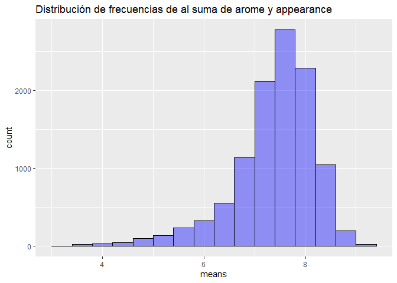

```r
pl <- ggplot(beers_comparison, aes(x=means))
pl +  geom_histogram(binwidth = 0.4, col='black', fill='blue', alpha=0.4) + ggtitle('Distribución de frecuencias de al suma de arome y appearance')
```

```r
setorder(beers_comparison, -means) # Criterion 2
datatable(head(beers_comparison))
```

|  | beer_beerid | aroma_mean | app_mean | N | means |
| --- | --- | --- | --- | --- | --- |
| 1 | 24273 | 4.78571428571429 | 4.48214285714286 | 28 | 9.26785714285714 |
| 2 | 68548 | 4.71538461538462 | 4.52307692307692 | 65 | 9.23846153846154 |
| 3 | 63649 | 4.75757575757576 | 4.46969696969697 | 33 | 9.22727272727273 |
| 4 | 21690 | 4.72377049180328 | 4.4827868852459 | 610 | 9.20655737704918 |
| 5 | 36316 | 4.52884615384615 | 4.64423076923077 | 156 | 9.17307692307692 |
| 6 | 42349 | 4.71710526315789 | 4.45065789473684 | 152 | 9.16776315789474 |

We search for the names as in the previous section, to answer the question:

```r
ids_comparison<-apply(beers_comparison[1,c("beer_beerid")],1, as.numeric) # Ids we are going to search in the main dataset

datatable(unique(beer_reviews[beer_beerid==ids_comparison[1],c("beer_name")]))
```

|  | beer_name |
| --- | --- |
| 1 | M Belgian-Style Barleywine |

Therefore, and according to the criteria applied, if what you like most is the aroma and appearance, I would recommend the **M Belgian-Style Barleywine** beer.

# Classification and classification characteristics

As classification ideas we will provide the following:

- Classification by manufacturer:
  - Popularity
  - Rating
  - Trend
- Classification by style:
  - Popularity
  - Rating
  - Trend
- Ranking by % of alcohol.

The variables we are going to take as reference for the classification are **review_overall**, **review_time** , **brewery_id** and **beer_style** and **beer_abv**.

```r
reviews_2012 <- beer_reviews[review_time>'2011-01-01',]
reviews_2012 <- reviews_2012[review_time<'2012-01-01',]
```

## Classification by manufacturer

```r
# We create the variables necessary for the classification
beer_reviews[ , ratings_brewerly := .N, by = brewery_id]
beer_reviews[ , mean_brewery := mean(review_overall), by = brewery_id]
brewery_info<-unique(beer_reviews[,c("brewery_id","brewery_name","ratings_brewerly","mean_brewery")])
```

### Popularity

```r
datatable(setorder(brewery_info, -ratings_brewerly))
```

|  | brewery_id | brewery_name | ratings_brewerly | mean_brewery |
| --- | --- | --- | --- | --- |
| 1 | 35 | Boston Beer Company (Samuel Adams) | 39444 | 3.68952185376737 |
| 2 | 10099 | Dogfish Head Brewery | 33839 | 3.83604716451432 |
| 3 | 147 | Stone Brewing Co. | 33066 | 4.04026794895058 |
| 4 | 140 | Sierra Nevada Brewing Co. | 28751 | 4.05620674063511 |
| 5 | 287 | Bell's Brewery, Inc. | 25191 | 3.9730657774602 |
| 6 | 132 | Rogue Ales | 24083 | 3.90879458539219 |
| 7 | 1199 | Founders Brewing Company | 20004 | 4.11455208958208 |
| 8 | 345 | Victory Brewing Company | 19479 | 3.99625237435187 |
| 9 | 220 | Lagunitas Brewing Company | 16837 | 3.95572251588763 |
| 10 | 30 | Avery Brewing Company | 16107 | 3.81458372136338 |

[output cut: 5830 more lines]

### Rating

```r
brewery_info2<-brewery_info[ratings_brewerly>=15,] # We choose the ones with enough comments
datatable(setorder(brewery_info2, -mean_brewery))
```

|  | brewery_id | brewery_name | ratings_brewerly | mean_brewery |
| --- | --- | --- | --- | --- |
| 1 | 5983 | Brauerei Zehendner GmbH | 28 | 4.60714285714286 |
| 2 | 27039 | The Alchemist | 527 | 4.58254269449715 |
| 3 | 313 | Brouwerij Westvleteren (Sint-Sixtusabdij van Westvleteren) | 2378 | 4.54499579478553 |
| 4 | 2805 | U Fleků Pivovaru a Restauraci | 30 | 4.51666666666667 |
| 5 | 22147 | Peg's Cantina &amp; Brewpub / Cycle Brewing | 79 | 4.50632911392405 |
| 6 | 2652 | Brauerei Schumacher | 19 | 4.42105263157895 |
| 7 | 863 | Russian River Brewing Company | 11311 | 4.3738838299001 |
| 8 | 10902 | Närke Kulturbryggeri AB | 212 | 4.36320754716981 |
| 9 | 464 | Badische Staatsbrauerei Rothaus AG | 126 | 4.35714285714286 |
| 10 | 237 | Quincy Ships Brewing Company | 17 | 4.35294117647059 |

[output cut: 2876 more lines]

### Trend

```r
reviews_2012[ , ratings_brewerly2012 := .N, by = brewery_id]
tendencia2012<-unique(reviews_2012[,c("brewery_id","brewery_name","ratings_brewerly2012")])
datatable(setorder(tendencia2012, -ratings_brewerly2012)) # Brewery trend during 2012
```

|  | brewery_id | brewery_name | ratings_brewerly2012 |
| --- | --- | --- | --- |
| 1 | 35 | Boston Beer Company (Samuel Adams) | 8355 |
| 2 | 140 | Sierra Nevada Brewing Co. | 7375 |
| 3 | 147 | Stone Brewing Co. | 7335 |
| 4 | 10099 | Dogfish Head Brewery | 7226 |
| 5 | 1199 | Founders Brewing Company | 5551 |
| 6 | 287 | Bell's Brewery, Inc. | 4826 |
| 7 | 220 | Lagunitas Brewing Company | 3985 |
| 8 | 192 | New Belgium Brewing | 3895 |
| 9 | 1549 | Goose Island Beer Co. | 3758 |
| 10 | 17981 | Cigar City Brewing | 3748 |

[output cut: 3770 more lines]

## Classification by style

```r
beer_reviews[ , rating_style := .N, by = beer_style]
beer_reviews[ , mean_style := mean(review_overall), by = beer_style]
style_info<-unique(beer_reviews[,c("beer_style","rating_style","mean_style")])
```

### Popularity

```r
datatable(setorder(style_info, -rating_style))
```

|  | beer_style | rating_style | mean_style |
| --- | --- | --- | --- |
| 1 | American IPA | 117586 | 3.9652211998027 |
| 2 | American Double / Imperial IPA | 85977 | 3.99801691149959 |
| 3 | American Pale Ale (APA) | 63469 | 3.85230585010005 |
| 4 | Russian Imperial Stout | 54129 | 4.02308374438841 |
| 5 | American Double / Imperial Stout | 50705 | 4.02981954442363 |
| 6 | American Porter | 50477 | 3.89573469104741 |
| 7 | American Amber / Red Ale | 45751 | 3.78101025114205 |
| 8 | Belgian Strong Dark Ale | 37743 | 3.91332167554248 |
| 9 | Fruit / Vegetable Beer | 33861 | 3.41512359351466 |
| 10 | American Strong Ale | 31945 | 3.87350133041164 |

[output cut: 94 more lines]

### Rating

```r
style_info2<-style_info[rating_style>=15,] # We choose the ones with enough comments
datatable(setorder(style_info2, -mean_style))
```

|  | beer_style | rating_style | mean_style |
| --- | --- | --- | --- |
| 1 | American Wild Ale | 17794 | 4.09326177363156 |
| 2 | Gueuze | 6009 | 4.08628723581295 |
| 3 | Quadrupel (Quad) | 18086 | 4.07162999004755 |
| 4 | Lambic - Unblended | 1114 | 4.04892280071813 |
| 5 | American Double / Imperial Stout | 50705 | 4.02981954442363 |
| 6 | Russian Imperial Stout | 54129 | 4.02308374438841 |
| 7 | Weizenbock | 9412 | 4.00796855078623 |
| 8 | American Double / Imperial IPA | 85977 | 3.99801691149959 |
| 9 | Flanders Red Ale | 6664 | 3.99272208883553 |
| 10 | Rye Beer | 10130 | 3.9817374136229 |

[output cut: 94 more lines]

### Trend

```r
reviews_2012[ , ratings_style2012 := .N, by = beer_style]
tendencia2012<-unique(reviews_2012[,c("beer_style","ratings_style2012")])
datatable(setorder(tendencia2012, -ratings_style2012)) # Brewery trend during 2012
```

|  | beer_style | ratings_style2012 |
| --- | --- | --- |
| 1 | American IPA | 28845 |
| 2 | American Double / Imperial IPA | 23956 |
| 3 | American Double / Imperial Stout | 15879 |
| 4 | Russian Imperial Stout | 13156 |
| 5 | American Pale Ale (APA) | 13083 |
| 6 | American Porter | 10924 |
| 7 | Saison / Farmhouse Ale | 9621 |
| 8 | American Amber / Red Ale | 8517 |
| 9 | American Strong Ale | 7683 |
| 10 | American Wild Ale | 6875 |

[output cut: 94 more lines]

## Classification by % alcohol

To make this classification correctly, we would need the opinion of an expert brewer. If we make it our own, we can base it on its frequency distribution:

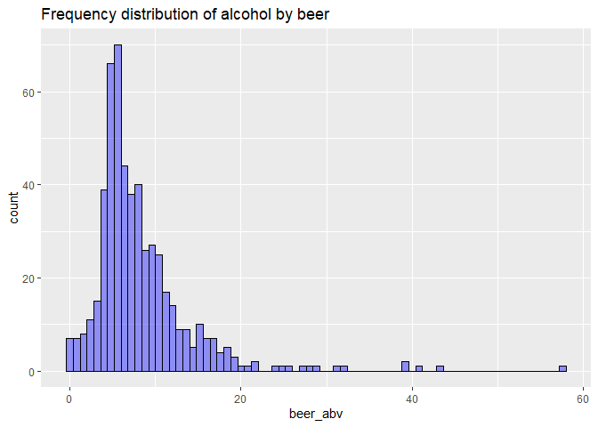

```r
beers_info<-unique(beer_reviews[,"beer_beerid","beer_abv"])
pl <- ggplot(beers_info, aes(x=beer_abv))
pl +  geom_histogram(binwidth = 0.8, col='black', fill='blue', alpha=0.4) + ggtitle('Frequency distribution of alcohol by beer')
```

In this case, we will apply a simple criterion of non-alcoholic beers, mild (0-3), normal (3-6) and strong (6-10) and very strong (>10). It would also be interesting to apply unsupervised learning methods such as K-means to make groupings of this variable.

```r
beers_info_freq <- cut(beers_info$beer_abv, breaks = c(0,0.1,3,6,10, Inf),
             labels = c('non', 'mild', 'normal','strong','very strong'), right = FALSE)

summary(beers_info_freq)
```

```
##         non        mild      normal      strong very strong        NA's
##           3          32         187         175         133           1
```

```r
beer_reviews$beer_abv <- cut(beer_reviews$beer_abv, breaks = c(0,0.1,3,6,10, Inf),
             labels = c('non', 'mild', 'normal','strong','very strong'), right = FALSE)

summary(beer_reviews$beer_abv)
```

```
##         non        mild      normal      strong very strong        NA's
##          23        3391      612256      708801      194358       67785
```

# Influence of the factors (arome, taste, appearance, palette) in determining the overall quality.

In this section, we are going to plan a GLM model to see the influence of the different ratings on the overall rating.

## GLM hypothesis testing

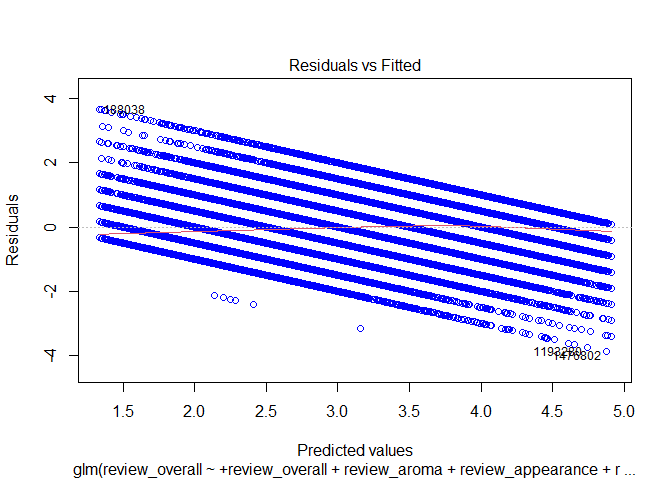

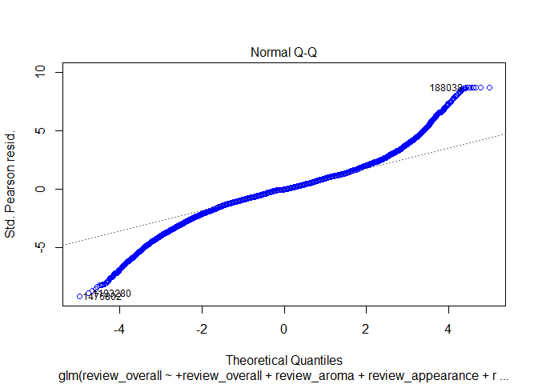

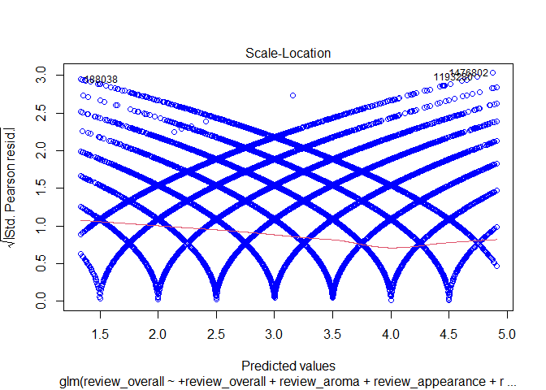

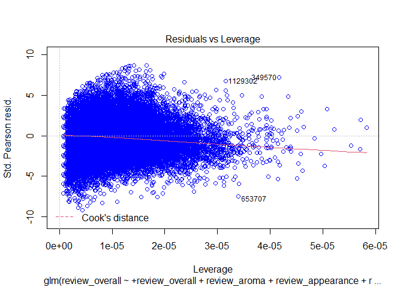

```r
modelo1 = glm(formula = review_overall~ +review_overall+review_aroma+review_appearance+review_palate+review_taste, data = beer_reviews)

plot(modelo1, col = "blue")
```

## Model fit and conclusions

```r
summary(modelo1)
```

```
##
## Call:
## glm(formula = review_overall ~ +review_overall + review_aroma +
##     review_appearance + review_palate + review_taste, data = beer_reviews)
##
## Deviance Residuals:
##     Min       1Q   Median       3Q      Max
## -3.8722  -0.2566  -0.0041   0.2441   3.6667
##
## Coefficients:
##                    Estimate Std. Error t value Pr(>|t|)
## (Intercept)       0.4395778  0.0023021  190.95   <2e-16 ***
## review_aroma      0.0478092  0.0007234   66.09   <2e-16 ***
## review_appearance 0.0358910  0.0006998   51.29   <2e-16 ***
## review_palate     0.2584742  0.0007599  340.14   <2e-16 ***
## review_taste      0.5515296  0.0007770  709.78   <2e-16 ***
## ---
## Signif. codes:  0 '***' 0.001 '**' 0.01 '*' 0.05 '.' 0.1 ' ' 1
##
## (Dispersion parameter for gaussian family taken to be 0.1775317)
##
##     Null deviance: 823922  on 1586613  degrees of freedom
## Residual deviance: 281673  on 1586609  degrees of freedom
## AIC: 1759992
##
## Number of Fisher Scoring iterations: 2
```

Based on this model, we can conclude:

- All ratings positively affect the overall rating.
- All variables are significant in explaining the overall rating.
- The variable **review_taste**, and therefore **the taste of a beer, has the greatest influence on the overall rating**.